# QGAM modelling of extreme rainfall in Switzerland: solution

Matteo Fasiolo

2019-06-24

```r
library(mgcViz);
library(gamair);
data(swer)

form <- exra ~ s(nao) + s(elevation) + climate.region + s(E, N) + s(year, k = 5)
fit <- qgamV(form, data = swer, qu = 0.5)
```

```
## Estimating learning rate. Each dot corresponds to a loss evaluation.
## qu = 0.5............done
```

```r
summary(fit)
```

```
##
## Family: elf
## Link function: identity
##
## Formula:
## exra ~ s(nao) + s(elevation) + climate.region + s(E, N) + s(year,
##     k = 5)
##
## Parametric coefficients:
##                                            Estimate Std. Error z value
## (Intercept)                                  69.197      3.837  18.032
## climate.regionCentral Alpine north slope    -24.735      4.896  -5.052
## climate.regionCentral plateau               -23.605      5.589  -4.224
## climate.regionEastern Alpine north slope    -15.030      5.848  -2.570
## climate.regionEastern Jura                  -21.128      6.168  -3.426
## climate.regionEngadine                      -18.319      3.699  -4.953
## climate.regionNorth-eastern plateau         -14.079      6.170  -2.282
## climate.regionNorthern and central Grisons  -15.273      4.243  -3.599
## climate.regionValais                        -29.723      5.204  -5.712
## climate.regionWestern Alpine north slope    -29.265      4.971  -5.887
## climate.regionWestern Jura                  -19.786      6.721  -2.944
## climate.regionWestern plateau               -20.285      6.315  -3.212
##                                            Pr(>|z|)
## (Intercept)                                 < 2e-16 ***
## climate.regionCentral Alpine north slope   4.38e-07 ***
## climate.regionCentral plateau              2.41e-05 ***
## climate.regionEastern Alpine north slope   0.010171 *
## climate.regionEastern Jura                 0.000613 ***
## climate.regionEngadine                     7.33e-07 ***
## climate.regionNorth-eastern plateau        0.022487 *
## climate.regionNorthern and central Grisons 0.000319 ***
## climate.regionValais                       1.12e-08 ***
## climate.regionWestern Alpine north slope   3.93e-09 ***
## climate.regionWestern Jura                 0.003241 **
## climate.regionWestern plateau              0.001317 **
## ---
## Signif. codes:  0 '***' 0.001 '**' 0.01 '*' 0.05 '.' 0.1 ' ' 1
##
## Approximate significance of smooth terms:
##                 edf Ref.df  Chi.sq  p-value
## s(nao)        6.473  7.539  29.378 0.000203 ***
## s(elevation)  6.080  7.026  94.101  < 2e-16 ***
## s(E,N)       23.842 26.994 299.595  < 2e-16 ***
## s(year)       1.019  1.038   0.009 0.922924
## ---
## Signif. codes:  0 '***' 0.001 '**' 0.01 '*' 0.05 '.' 0.1 ' ' 1
##
## R-sq.(adj) =  0.486   Deviance explained = 38.2%
## -REML = 9182.8  Scale est. = 1         n = 2196
```

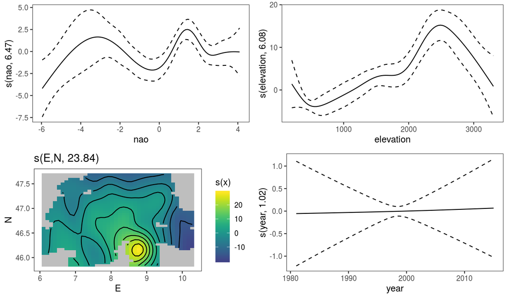

```r
print(plot(fit), pages = 1)
```

2. Fit a smooth trend for each climate region:

```r
fit2 <- qgamV(exra ~ s(nao) + s(elevation) +
                     s(year, climate.region, bs = "fs", k = 5) + s(E, N),
                     data = swer, qu = 0.5)
```

```
## Estimating learning rate. Each dot corresponds to a loss evaluation.
## qu = 0.5............done
```

```r
summary(fit2)
```

```
##
## Family: elf
## Link function: identity
##
## Formula:
## exra ~ s(nao) + s(elevation) + s(year, climate.region, bs = "fs",
##     k = 5) + s(E, N)
##
## Parametric coefficients:
##             Estimate Std. Error z value Pr(>|z|)
## (Intercept)   50.086      1.778   28.17   <2e-16 ***
## ---
## Signif. codes:  0 '***' 0.001 '**' 0.01 '*' 0.05 '.' 0.1 ' ' 1
##
## Approximate significance of smooth terms:
##                           edf Ref.df Chi.sq  p-value
## s(nao)                  6.584  7.628  31.15 0.000105 ***
## s(elevation)            5.936  6.865 109.50  < 2e-16 ***
## s(year,climate.region) 14.930 59.000  55.01  8.8e-11 ***
## s(E,N)                 25.348 27.628 336.70  < 2e-16 ***
## ---
## Signif. codes:  0 '***' 0.001 '**' 0.01 '*' 0.05 '.' 0.1 ' ' 1
##
## R-sq.(adj) =  0.489   Deviance explained = 38.6%
## -REML = 9217.3  Scale est. = 1         n = 2196
```

```r
AIC(fit) - AIC(fit2)
```

```
## [1] 12.8558
```

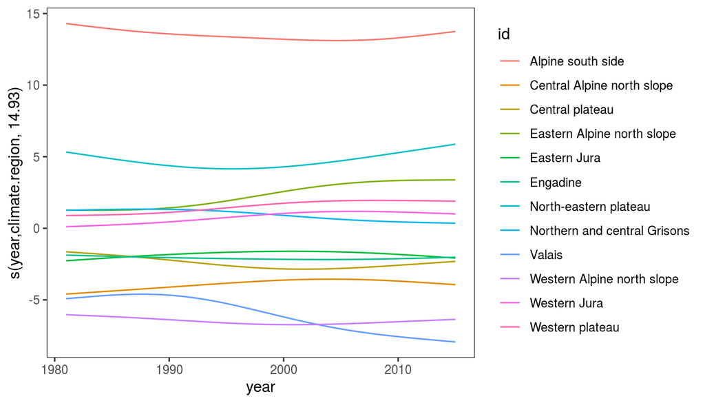

```r
plot(sm(fit2, 3)) + l_fitLine(alpha = 1)
```

The effect of year-by-region is using relatively few degrees of freedom (`edf`), there might have been a slight decrease in rainfall in Valais, for instance.

3. Fit a 3D spatio-temporal tensor product effect:

```r
fit <- qgamV(exra ~ s(nao) + s(elevation) + climate.region +
                    te(E, N, year, d = c(2, 1), k = c(20, 5)),
                    data = swer, qu = 0.5)
```

```
## Estimating learning rate. Each dot corresponds to a loss evaluation.
## qu = 0.5.........done
```

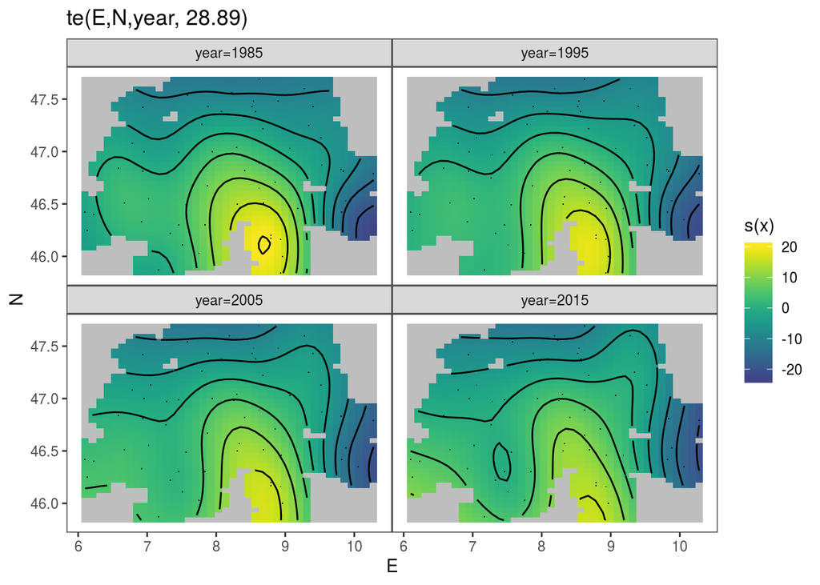

```r
plotSlice(x = sm(fit, 3),
          fix = list("year" = c(1985, 1995, 2005, 2015))) + l_fitRaster() +
          l_fitContour() + l_points()
```

There doesn’t seem to be much change in the precipication pattern, maybe there is a decrease of rainfall levels in the South East (in the Canton of Ticino).

4. We plot one slice through time using `rgl`:

```r
plotRGL(x = sm(fit, 3), fix = c("year" = 1985), residuals = TRUE)
rglwidget()
```

[interactive chart not shown]

5. Remove the tensor effect w.r.t. time and fit the model to several quantiles:

```r
fitM <- mqgamV(exra ~ s(nao) + s(elevation) + climate.region + s(E, N) + s(year, k = 5),
               data = swer, qu = seq(0.1, 0.9, length.out = 9) )
```

```
## Estimating learning rate. Each dot corresponds to a loss evaluation.
## qu = 0.5............done
## qu = 0.4............done
## qu = 0.6...........done
## qu = 0.3.........done
## qu = 0.7............done
## qu = 0.2............done
## qu = 0.8.........done
## qu = 0.1......................done
## qu = 0.9...........done
```

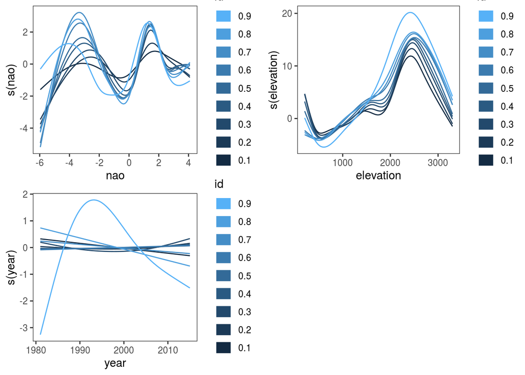

```r
# Plot univariate smooths
print(plot(fitM, select = c(1, 2, 4)), pages = 1)
```

```r
summary(fitM[[9]])
```

```
##
## Family: elf
## Link function: identity
##
## Formula:
## exra ~ s(nao) + s(elevation) + climate.region + s(E, N) + s(year,
##     k = 5)
##
## Parametric coefficients:
##                                            Estimate Std. Error z value
## (Intercept)                                  98.575      7.677  12.840
## climate.regionCentral Alpine north slope    -24.755      9.538  -2.595
## climate.regionCentral plateau               -30.285     11.390  -2.659
## climate.regionEastern Alpine north slope    -10.054     12.181  -0.825
## climate.regionEastern Jura                  -25.775     12.436  -2.073
## climate.regionEngadine                      -20.299      7.154  -2.837
## climate.regionNorth-eastern plateau         -23.751     12.637  -1.880
## climate.regionNorthern and central Grisons  -11.611      7.828  -1.483
## climate.regionValais                        -33.705     10.355  -3.255
## climate.regionWestern Alpine north slope    -33.916      9.728  -3.486
## climate.regionWestern Jura                  -21.651     14.015  -1.545
## climate.regionWestern plateau               -22.500     13.004  -1.730
##                                            Pr(>|z|)
## (Intercept)                                 < 2e-16 ***
## climate.regionCentral Alpine north slope    0.00945 **
## climate.regionCentral plateau               0.00784 **
## climate.regionEastern Alpine north slope    0.40912
## climate.regionEastern Jura                  0.03821 *
## climate.regionEngadine                      0.00455 **
## climate.regionNorth-eastern plateau         0.06017 .
## climate.regionNorthern and central Grisons  0.13801
## climate.regionValais                        0.00113 **
## climate.regionWestern Alpine north slope    0.00049 ***
## climate.regionWestern Jura                  0.12237
## climate.regionWestern plateau               0.08358 .
## ---
## Signif. codes:  0 '***' 0.001 '**' 0.01 '*' 0.05 '.' 0.1 ' ' 1
##
## Approximate significance of smooth terms:
##                 edf Ref.df  Chi.sq  p-value
## s(nao)        4.567  5.501   9.533    0.197
## s(elevation)  4.356  5.173  44.842 2.23e-08 ***
## s(E,N)       23.818 26.978 226.415  < 2e-16 ***
## s(year)       2.439  2.929   4.136    0.173
## ---
## Signif. codes:  0 '***' 0.001 '**' 0.01 '*' 0.05 '.' 0.1 ' ' 1
##
## R-sq.(adj) =  0.403   Deviance explained = 70.8%
## -REML =  10699  Scale est. = 1         n = 2196
```

It seems that the effect of `NAO` is very weak for extreme quantiles, however the reason for this might simply be that the data is quite sparse in the tails. Also, the effect of `year` seems to be highly non-linear for quantile 0.9, but `summary` shows that this effect is not significant.

We can also plot the spatial effect:

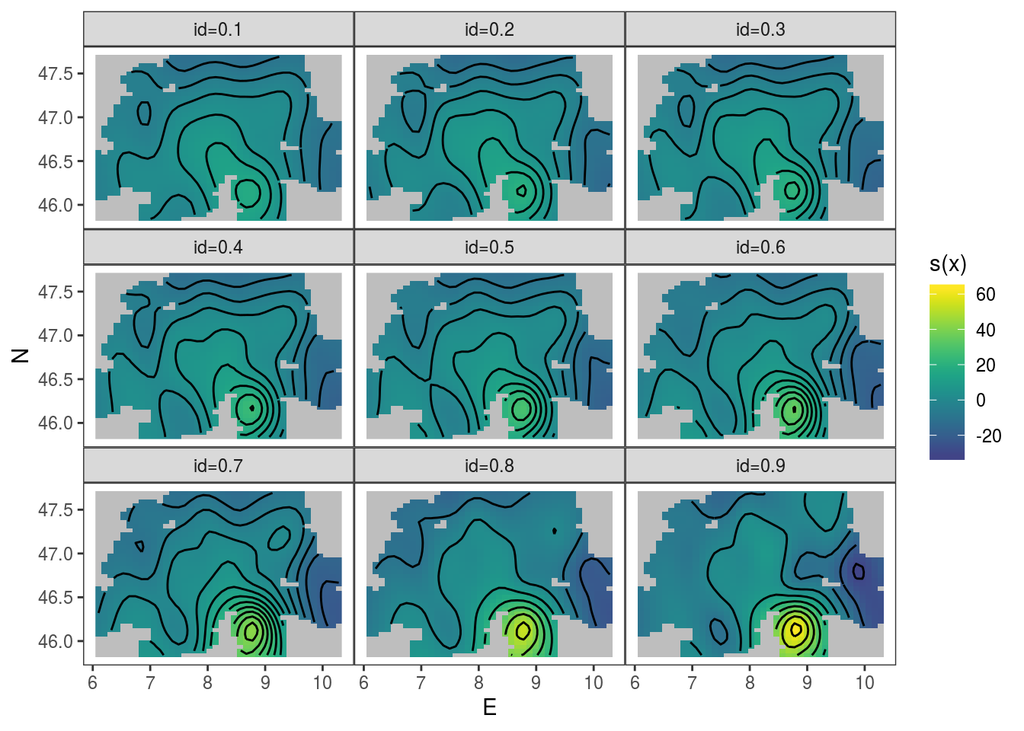

```r
print(plot(fitM, select = 3), pages = 1)
```

Finally we can see how the climate region effect changes depending on the quantile of interest:

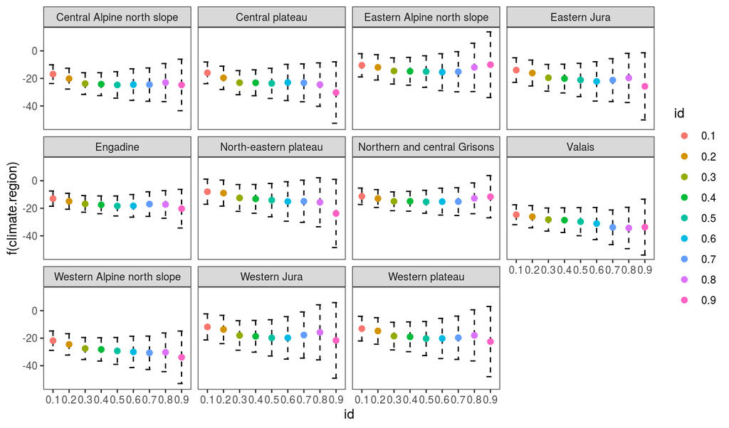

```r
print(plot(fitM, select = 5), pages = 1)
```